# Projet LSTAT2110(A) – Analyse de données

Etude des mesures physiques des abalones par âge et sexe

Louis Descarpentries (3004 18 00 - BIRE2M) - Mattias VAN EETVELT (1660 18 00 - BIRE2M)

# Introduction

La première méthode consiste en une Analyse en Composantes Principales (ACP). Il s’agit d’une méthode de projection projetant les observations d’un espace à $p$ dimensions avec $p$ variables vers un espace à $k$ dimensions où $k < p$. Ainsi, cette technique permet de simplifier la visualisation de la matrice de données, mais aussi de transformer les variables initiales en variables non corrélées (diminue la redondance) (XLSTAT,2022). Ces nouvelles variables sont appelées Composantes Principales, classées en fonction de leur degré de similarité par rapport à l’initial.

Ces étapes préalables sont nécessaires pour diverses représentations graphiques par la suite, comme le cercle des corrélations (corrélations entre les composantes) et la carte des individus (individus en fonction des composantes principales).

La seconde méthode correspond à une analyse de classification, permettant de grouper des objets dans des classes, en fonction de leur degré de similarité (les objets les plus similaires sont regroupés dans la même classe). Cette seconde méthode peut se diviser en plusieurs analyses de classification comme : classification hiérarchique, K-means clustering, analyse discriminante Linéaire (XLSTAT, 2022).

# Présentation des données et analyse descriptives

## Présentation des données

La base de données utilisée dans le cadre de ce projet est issue du site Kaggle, une plateforme web appartenant à Google qui rassemble des bases de données, du code utile au traitement de certaines problématiques du domaine de la Sciences des données, et plus largement, une plateforme qui permet des échanges entre passionnés, professionnels et novices de la Science des données (Kaggle, 2021).

Dans le cadre de ce projet, la base de données choisie a été publié en 2018 sur la plateforme par Rodolfo Mendes. Il est à noter que M. Mendes n’est pas le producteur des chiffres présentés car il se base sur les données issues d’une étude réalisée en 1994 par Warwick J Nash, Tracy L Sellers, Simon R Talbot, Andrew J Cawthorn et Wes B Ford dont les chiffres ont été publié par Sam Waugh du département d’informatique de l’Université de Tasmanie (UCI, 1995).

L’objet de la base de données concerne les ormeaux ou Abalone, et plus particulièrement les mesures physiques de ceux-ci. Le but original était de catégoriser les mollusques selon leur âge sur base de mesures physiques (détail dans la suite de la section) et ensuite pouvoir établir un modèle d’extrapolation à l’ensemble de la population pour connaître l’âge sans avoir à faire des mesures sur le terrain.

Avant tout développement, et de manière à faciliter la compréhension dans la suite du rapport, il semble important de décrire les caractéristiques de l’ormeau. Haliotis tuberculata ou ormeau est un mollusque mesurant 8 à 11 cm à maturité possédant une coquille ovale, aplatie, en forme d’oreille et percée de trous alignés suivant sa croissance lui facilitant sa respiration. L’intérieur de sa coquille est nacré, ce qui le rend convoité dans la fabrication de bijoux par exemple. Cette espèce est présente en Méditerranée, en Atlantique nord, dans la Manche, en Mer du Nord et se développe dans des environnements rocailleux car elle se nourrit d’algue en rappant les roches. L’ormeau est très convoité en gastronomie, ce qui a mené à sa surpêche dans différents pays, lui conférant aujourd’hui un statut de protection et des normes de pêche très réglementées. Toutefois, l’élevage d’ormeau s’est développé ces dix dernières années, et ce notamment en France (Muséum-Aquarium de Nancy, s.d.).

La matrice étudiée comporte **8 variables quantitatives**, représentant différentes mesures physiques du mollusque à savoir : LongestShell (longueur de la coquille en mm), Diameter (diamètre perpendiculaire à la longueur en mm), Height (hauteur avec viande dans la coquille en mm), WholeWeight (poids entier en grammes), ShuckedWeight (poids entier une fois décoquillé en gramme) , VisceraWeight (poids boyaux après saignée en grammes), ShellWeight (poids coquille après séchage en grammes), Rings (nombre d’anneaux, donne l’âge lorsqu’on additionne 1,5 au chiffre). La base de données reprend également une variable catégorielle nommée type qui reprend **trois types de mollusques** : M pour Male, F pour Female et I pour Infant. Enfin, le jeu de données est divisé en **4177 observations** divisées équitablement (37% de mâles, 32% de jeunes, 31% de femelles) entre I (infant), M (male), F (female).

Finalement, il est évident que ce type de données est relativement important pour étudier la dynamique des populations d’ormeau. En effet, comme énoncé précédemment, le modèle mathématique réalisé sur base de cette base de données, et une fois couplé avec des facteurs extérieurs, permet de connaître l’âge des individus. Cela n’est pas anodin car ces coquillages sont menacés par le changement climatique, et plus précisément l’acidification des océans, mais aussi la surexploitation. Par conséquent, connaître les écosystèmes les plus favorables au développement de l’espèce pourrait favoriser leur protection (BOREA, 2017).

## Analyse descriptive

Afin d’avoir un aperçu génerale des données, la fonction `summary()` est utilisée. Celle-ci permet d’avoir des informations sur des quantiles, minimum et maximum, médiane et moyenne de chaque variable. Afin de rester concis, seules les moyennes de chaque variables selon leur catégorie respective sont présentées. Néanmois, l’output complet de la fonction `summary()` est présenté en annexe. Les longueurs sont en millimètres tandis que les poids sont en grammes.

```
         LongestShell Diameter Height WholeWeight ShuckedWeight VisceraWeight
moyennes        0.524    0.408   0.14       0.829         0.359         0.181
         ShellWeight Rings
moyennes       0.239 9.934
```

On observe que le poids total (`WholeWeight`) est principalement composé par le poids total une fois décoquillé (`ShuckedWeight`) ainsi que par le poids de la coquille. Le poids des boyaux après la saignée (`VisecraWeight`), ne représente quant à elle qu’environ 20% du poids total.

Dans un second temps, il est intéressant d’analyser la matrice de correlation afin d’avoir une idée des correlations entre les différentes variables quantitatives. Les variables fortement correlées auront une correlation de 1 et dans le cas contraire, de -1. Une correlation de 0 indiquera une indépendance des variables.

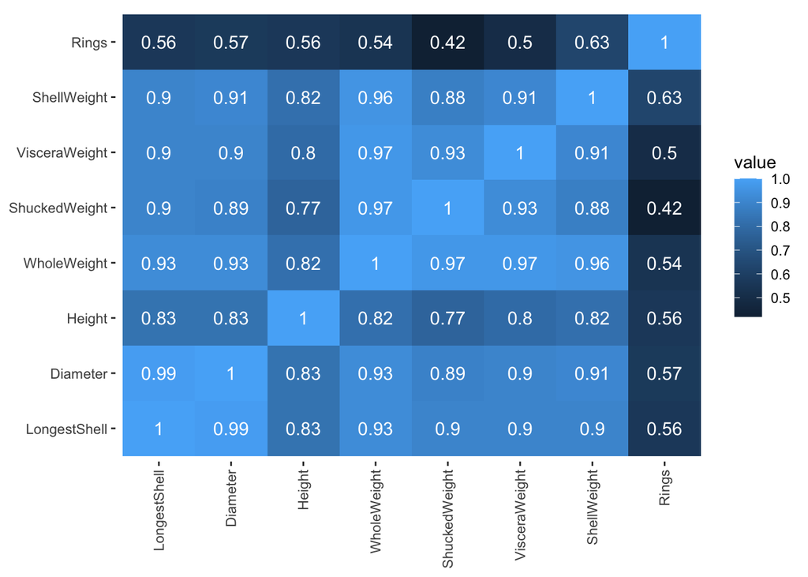

# Analyse en composante principales

L’analyse descriptive permet d’avoir une idée globale des relations entre les variables et des moyennes générales, mais reste assez floue vu le nombre de variables et d’individus que comporte la base de données choisie. L’Analyse en Composantes Principales va permettre de réduire ces dimensions afin de faciliter l’interprétation. L’objectif de cette partie est donc de trouver des liens clairs entre les différentes variables et d’observer comment les individus sont influencés par celles-ci.

## Application de l’Analyse en Composantes Principales (ACP)

On observe que la première composante apporte énormément d’informations comparé aux autres composantes. La quantité d’information approtée par le deuxième, troisième et quatrième composante est non négligeable, ce qui n’est pas le cas pour les quatres dernières.

```
      [,1]   [,2]   [,3]  [,4]   [,5]   [,6]   [,7]   [,8]
VaP 6.7124 0.6956 0.2584 0.166 0.0849 0.0635 0.0127 0.0064
```

On s’intèresse ensuite au pourcentage de la variance ainsi qu’au pourcentage de la variance cumulée. Cela permet de mettre en évidence la quantité d’information retenue par chaque composante.

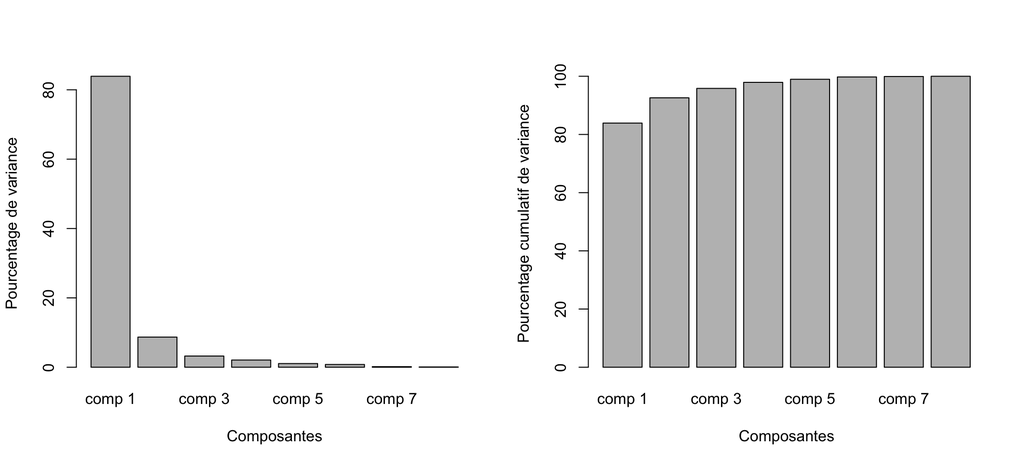

Pourcentages de variance et de variance cumulée

La première composante correspond à une valeur propre de 6,71 et capte à elle seule 83,9% de la variance totale tandis que la deuxième composante en capte 8,69%. C’est-à-dire que les deux premières composantes captent à elles seules 92,6% de la variance totale. On notera tout de même que la troisième et quatrième composantes captent respectivement 3,23% et 2,07% de la variance totale, ce qui est relativement faible en soit mais largement supérieur aux dernières composantes.

## Choix des composantes principales retenues

Pour interpréter et visualiser les résultats de l’analyse en composantes principales, il faut choisir le nombre de composantes à garder. Une limite arbitraire souvent fixée est de garder toutes les composantes dont la valeur propre est supérieure à 1. Ceci est visible sur la figure 2.

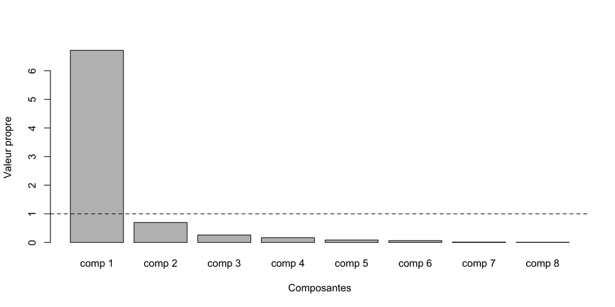

Composantes principales à garder

Seule une seule composante possède une valeur supérieur à 1. Cependant, il faut au minimum deux composantes afin de pouvoir visualier les résultats en 2D. Il semble dès lors logique de choisir la composante avec la seconde valeur la plus élevée, la composante numéro 2.

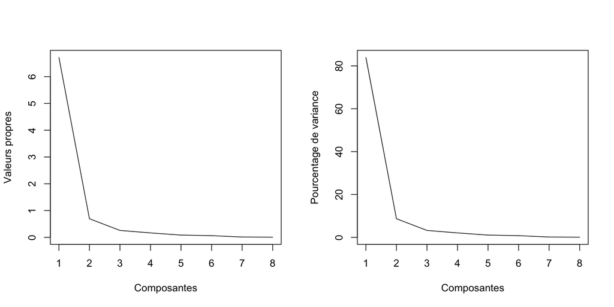

Valeurs propres et pourcentages de variance

## Résultats et discussion

### Analyse des variables

Le choix de garder deux composantes pincipales simplifie la représentation mais a comme conséquence de ne représenter correctement que certaines variables. Les variables considérées comme mal représentées dans le plan choisi sont celles qui auront un angle de plus de 45° avec ce plan ($cos^2$ > 0,5).

Les valeurs ci-dessous représente la qualité de représentation dans le premier plan factoriel. On observe que toutes les variables sont bien représentées. Seule la variable `Height` a un $cos^2$ inférieur à 0.9 mais cela reste une valeur acceptable. Concernant les contributions, toutes les variables sauf `Rings` contribuent avec une valeur de l’ordre de 15% dans la dimension 1 tandis que `Rings` contribue à 84 % dans la dimension 2 et uniquement 5% dans la dimension 1. Le détail de toutes les dimensions est présenté en annexe.

[output not shown]

Finalement, le cercle de corrélation est présenté sur la figure 4. Cela permet de visualiser les résultats discutés ci-dessus. On observe que toutes les variables sont bien représentées. En effet, la longueur des flèches est proche de 1, correspondant à $cos^2$, sauf celle de la variable `Height`. De plus, `Rings` est la seule variable dont la représentation est de bonne qualité dans la dimension 2, toutes les autres variables sont bien représentées dans la dimension 1, mais pas dans la dimension 2. On notera que le pourcentage de variance captée par les diférents axes est visible le long de ceux-ci. Une figure de plus grande taille est prensentée en annexe pour plus de lisibilité.

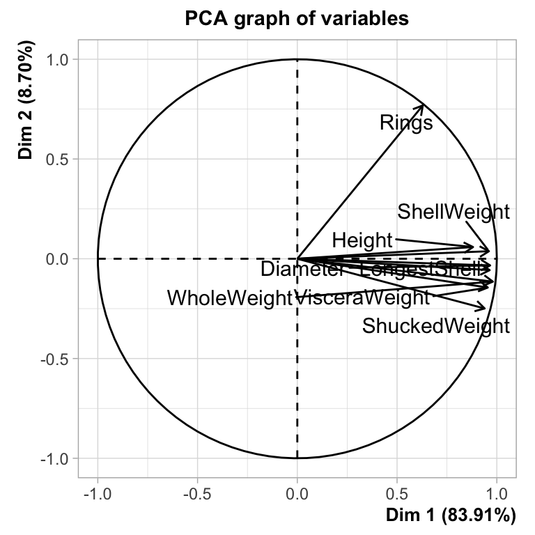

Cercle de corrélation

### Analyse des individus

Etant donné le nombre important d’individus (>4000), il n’est pas pertinent de présenter les résultats concernant la qualité de preprésentation pour tous les individus. Une alternative est la représentation visuelle et son interprétation.

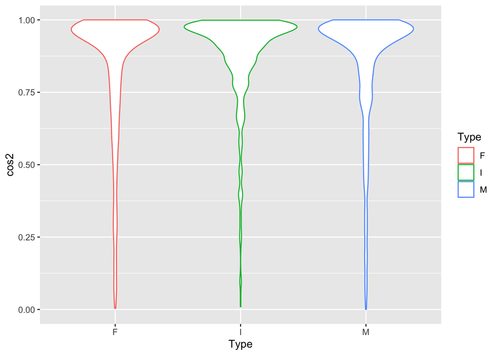

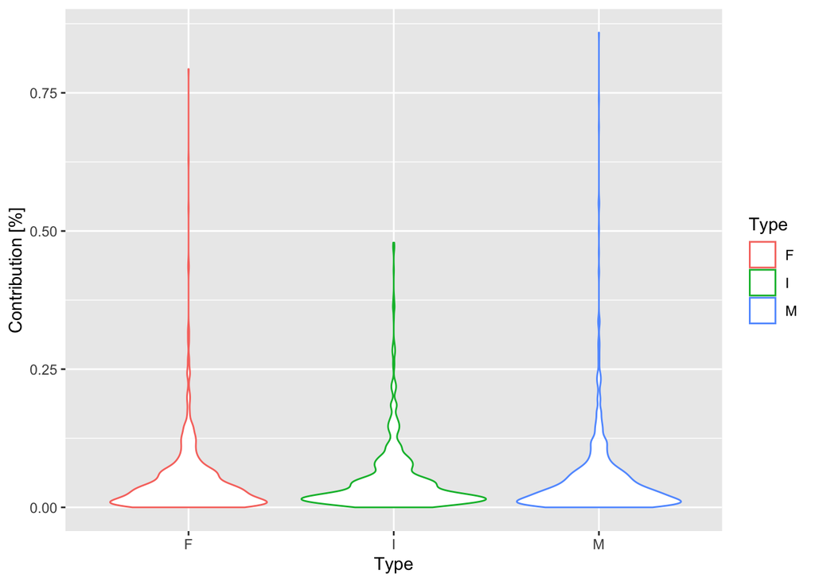

Distribution du score $cos^2$ ainsi que la contribution pour le premier plan factoriel pour les individus

La carte des individus permet de visualiser le lien entre les individus et les composantes principales.

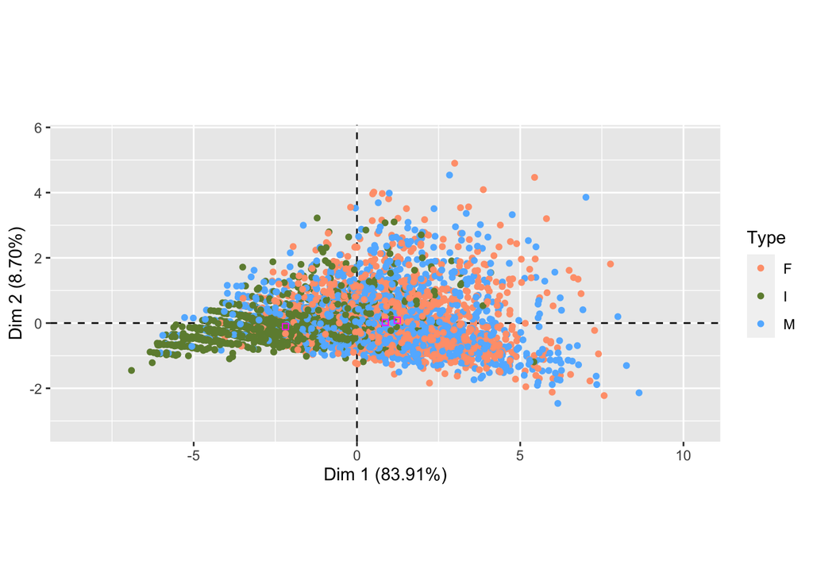

# Analyse de classification : Analyse discriminante linéaire

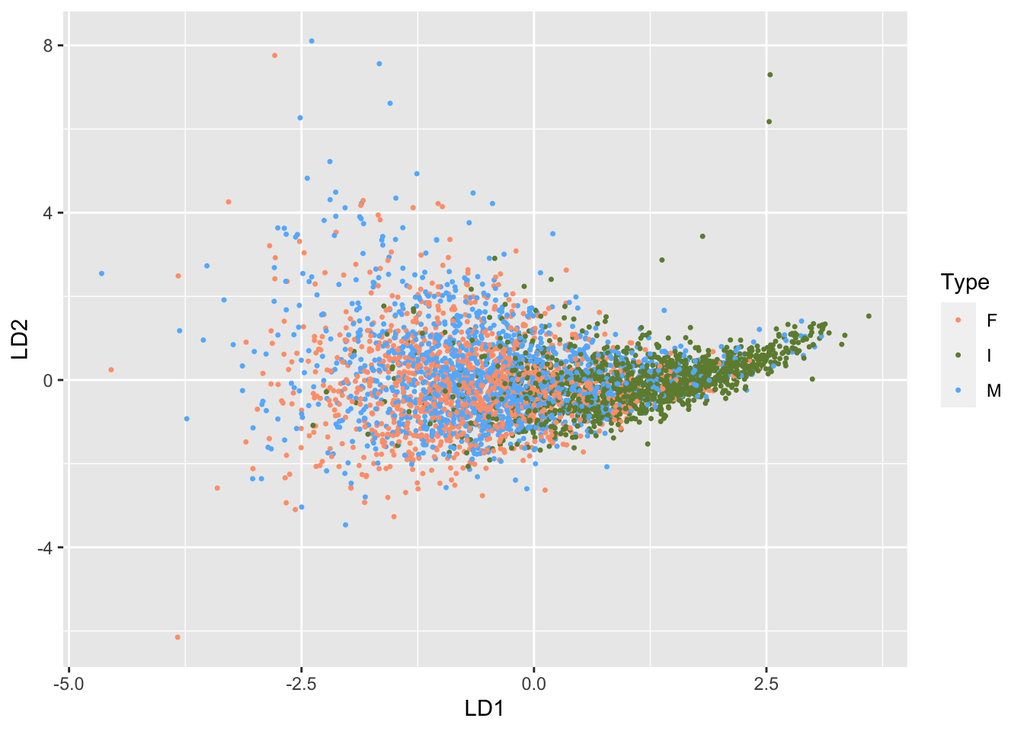

|  | LongestShell | Diameter | Height | WholeWeight | ShuckedWeight | VisceraWeight | ShellWeight | Rings |
| --- | --- | --- | --- | --- | --- | --- | --- | --- |
| new | 0.4 | 0.3 | 0.09 | 0.5 | 0.2 | 0.1 | 0.15 | 12 |

```
           new
Prédiction "I"
```

## Qualité

```
   Dataset.pred
       F    I    M
  F  445  189  673
  I   60 1032  250
  M  394  317  817
```

```
[1] 0.549198
```

# Annexe

## Analyse descriptive

### Détail de la fonction `summary`

```
 Type      LongestShell      Diameter          Height        WholeWeight
 F:1307   Min.   :0.075   Min.   :0.0550   Min.   :0.0000   Min.   :0.0020
 I:1342   1st Qu.:0.450   1st Qu.:0.3500   1st Qu.:0.1150   1st Qu.:0.4415
 M:1528   Median :0.545   Median :0.4250   Median :0.1400   Median :0.7995
          Mean   :0.524   Mean   :0.4079   Mean   :0.1395   Mean   :0.8287
          3rd Qu.:0.615   3rd Qu.:0.4800   3rd Qu.:0.1650   3rd Qu.:1.1530
          Max.   :0.815   Max.   :0.6500   Max.   :1.1300   Max.   :2.8255
 ShuckedWeight    VisceraWeight     ShellWeight         Rings
 Min.   :0.0010   Min.   :0.0005   Min.   :0.0015   Min.   : 1.000
 1st Qu.:0.1860   1st Qu.:0.0935   1st Qu.:0.1300   1st Qu.: 8.000
 Median :0.3360   Median :0.1710   Median :0.2340   Median : 9.000
 Mean   :0.3594   Mean   :0.1806   Mean   :0.2388   Mean   : 9.934
 3rd Qu.:0.5020   3rd Qu.:0.2530   3rd Qu.:0.3290   3rd Qu.:11.000
 Max.   :1.4880   Max.   :0.7600   Max.   :1.0050   Max.   :29.000
```

## Analyse en composantes principales

### Analyse des variables

#### Score pour $cos^2$

```
                  Dim.1       Dim.2        Dim.3        Dim.4        Dim.5
LongestShell  0.9295860 0.003243314 0.0002494918 0.0605664821 1.051356e-05
Diameter      0.9343663 0.001115656 0.0004345503 0.0573109036 2.848945e-04
Height        0.7760802 0.003453757 0.2092020069 0.0109444486 2.733858e-04
WholeWeight   0.9606611 0.013122027 0.0109879172 0.0097088981 2.082101e-05
ShuckedWeight 0.8818350 0.062121924 0.0112120853 0.0055737682 1.349191e-02
VisceraWeight 0.9117832 0.020813830 0.0100686034 0.0116760487 8.154263e-03
ShellWeight   0.9227010 0.001433795 0.0067469633 0.0098979354 5.860135e-02
Rings         0.3954264 0.590308665 0.0095415025 0.0003113583 4.112524e-03
```

#### Score pour la contribution

```
                  Dim.1      Dim.2       Dim.3      Dim.4       Dim.5
LongestShell  13.848707  0.4662527  0.09653645 36.4880652  0.01237622
Diameter      13.919922  0.1603846  0.16814155 34.5267533  0.33536857
Height        11.561821  0.4965055 80.94702091  6.5934448  0.32182095
WholeWeight   14.311655  1.8863977  4.25158045  5.8490917  0.02450982
ShuckedWeight 13.137326  8.9305299  4.33831832  3.3578971 15.88224146
VisceraWeight 13.583485  2.9921567  3.89586820  7.0341947  9.59893551
ShellWeight   13.746136  0.2061197  2.61061827  5.9629765 68.98361705
Rings          5.890949 84.8616534  3.69191583  0.1875767  4.84113042
```

## Cercle de corrélation

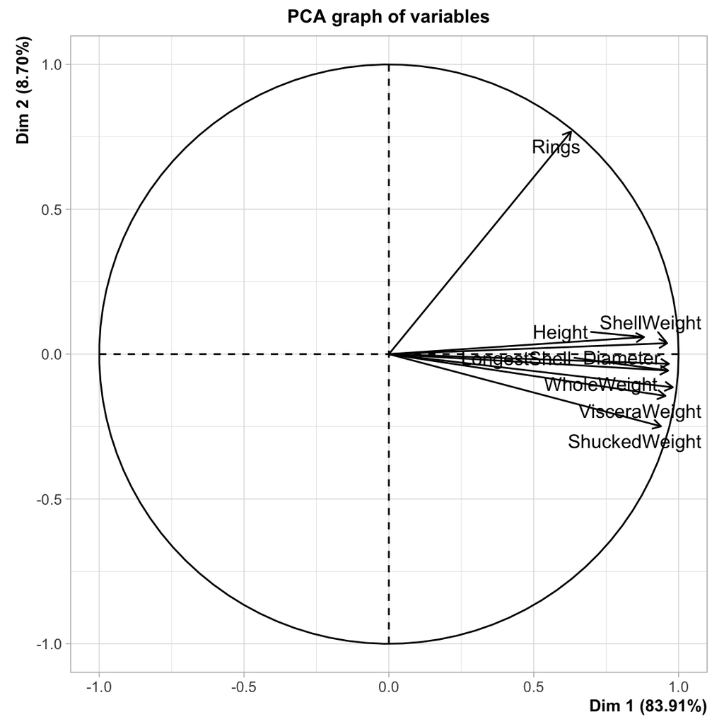

Cercle de corrélation